# Evasão de alunos UFCG - Relatório

Lilia Sampaio

February 13, 2015

### Importando datasets reorganizados

Para essa análise dois datasets foram fornecidos, um de treino chamado *dadosAlunos* e um de teste chamado *dadosTeste*. Considerando o problema de predizer quais alunos vao evadir os cursos de Computação e Engenharia Mecânica, e, ainda, que as análises devem ser feitas para os dois cursos em conjunto, e separadamente, os seguintes conjuntos de dados, de treino e teste, foram criados:

```r
all_alunos <- read.csv("new_all_alunos.csv", sep=",")
teste_all_alunos <- read.csv("t_new_all_alunos.csv", sep=",")

comp_alunos <- read.csv("comp_all_alunos.csv", sep=",")
teste_comp_alunos <- read.csv("comp_t_new_all_alunos.csv", sep=",")

mec_alunos <- read.csv("mec_all_alunos.csv", sep=",")
teste_mec_alunos <- read.csv("mec_t_new_all_alunos.csv", sep=",")
```

### Como os dados estão estruturados?

Depois de considerar os atributos existentes, e pensar em quais seriam decisivos para a predição a ser realizada, os dados foram tratados para chegar a seguinte configuração de variáveis:

```r
str(all_alunos)
```

```
## 'data.frame':    381 obs. of  7 variables:
##  $ MATRICULA   : int  292860458 292860461 292860470 292860473 292860476 292860479 292860485 292860488 292860491 292860500 ...
##  $ COD_EVASAO  : int  0 0 0 0 0 0 0 0 0 0 ...
##  $ MEDIA       : num  8.7 6.82 7.28 7.94 7.23 ...
##  $ REPROVADO   : int  0 1 0 0 0 0 0 0 0 0 ...
##  $ REP_FALTA   : int  0 0 0 0 0 0 0 0 0 0 ...
##  $ TRANCOU     : int  0 0 0 0 0 0 1 0 0 2 ...
##  $ NUM_CURSADAS: int  4 6 4 5 6 6 6 4 6 6 ...
```

Numa análise superficial dos dados, mais especificamente da variável que queremos predizer para o nosso conjunto de teste (COD_EVASAO), temos que,

```r
table(all_alunos$COD_EVASAO)
```

```
##
##   0   1
## 342  39
```

sendo 0 = não evadiu, e 1 = evadiu, 342 alunos não evadiram enquanto 39 sim. É uma diferença considerável que já nos permite fazer suposições na nossa predição, como por exemplo considerar que nenhum aluno evadirá. No entanto, isso não é uma boa prática, pois nesse caso, é pior errar dizendo que o aluno vai evadir e ele não evadir de verdade, do que dizer que ele não vai evadir, e a evasão acontecer. Dessa forma, utilizaremos arvores de decisão para tentar predizer com maior acurácia e precisão.

### Criando Árvore de Decisão

[output not shown]

### Alunos dos dois cursos

- Considerando todos os atributos, temos que

```r
tree_all_alunos <- rpart(COD_EVASAO ~ MEDIA + REPROVADO + REP_FALTA + TRANCOU + NUM_CURSADAS, data=all_alunos, method="class")
summary(tree_all_alunos)
```

```
## Call:
## rpart(formula = COD_EVASAO ~ MEDIA + REPROVADO + REP_FALTA +
##     TRANCOU + NUM_CURSADAS, data = all_alunos, method = "class")
##   n= 381
##
##          CP nsplit rel error    xerror      xstd
## 1 0.1452991      0 1.0000000 1.0000000 0.1517114
## 2 0.0100000      3 0.5641026 0.6923077 0.1284270
##
## Variable importance
##        MEDIA    REP_FALTA      TRANCOU NUM_CURSADAS    REPROVADO
##           47           21           21            6            5
##
## Node number 1: 381 observations,    complexity param=0.1452991
##   predicted class=0  expected loss=0.1023622  P(node) =1
##     class counts:   342    39
##    probabilities: 0.898 0.102
##   left son=2 (332 obs) right son=3 (49 obs)
##   Primary splits:
##       MEDIA        < 1.816667   to the right, improve=22.6383200, (0 missing)
##       REP_FALTA    < 1.5        to the left,  improve=12.3366900, (0 missing)
##       TRANCOU      < 4          to the left,  improve= 5.3404230, (0 missing)
##       NUM_CURSADAS < 5.5        to the right, improve= 1.5314140, (0 missing)
##       REPROVADO    < 0.5        to the left,  improve= 0.9420759, (0 missing)
##   Surrogate splits:
##       REP_FALTA < 2.5        to the left,  agree=0.927, adj=0.429, (0 split)
##       TRANCOU   < 0.5        to the left,  agree=0.921, adj=0.388, (0 split)
##
## Node number 2: 332 observations
##   predicted class=0  expected loss=0.03614458  P(node) =0.8713911
##     class counts:   320    12
##    probabilities: 0.964 0.036
##
## Node number 3: 49 observations,    complexity param=0.1452991
##   predicted class=1  expected loss=0.4489796  P(node) =0.1286089
##     class counts:    22    27
##    probabilities: 0.449 0.551
##   left son=6 (35 obs) right son=7 (14 obs)
##   Primary splits:
##       NUM_CURSADAS < 5.5        to the right, improve=3.6734690, (0 missing)
```

[output cut: 22 more lines]

```
##
## Node number 7: 14 observations
##   predicted class=1  expected loss=0.1428571  P(node) =0.03674541
##     class counts:     2    12
##    probabilities: 0.143 0.857
##
## Node number 12: 20 observations
##   predicted class=0  expected loss=0.2  P(node) =0.05249344
##     class counts:    16     4
##    probabilities: 0.800 0.200
##
## Node number 13: 15 observations
##   predicted class=1  expected loss=0.2666667  P(node) =0.03937008
##     class counts:     4    11
##    probabilities: 0.267 0.733
```

Se dermos uma olhada no campo referente à importancia das variaveis (Variable importance) teremos que a mais importante foi a MEDIA, seguida de REP_FALTA, TRANCOU, NUM_CURSADAS e REPROVADO.

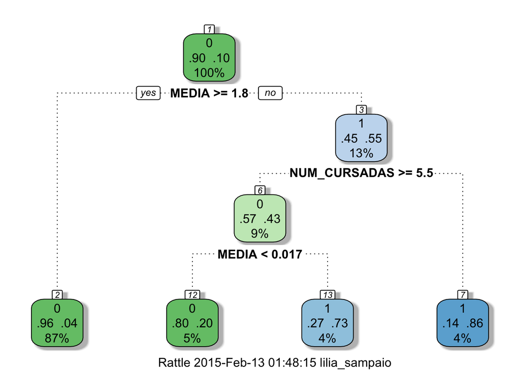

- Se ignorarmos os dados referentes a trancamento, que na teoria não pode acontecer no primeiro periodo (conjunto de dados considerado aqui), temos que

```r
tree_all_alunos <- rpart(COD_EVASAO ~ MEDIA + REPROVADO + REP_FALTA + NUM_CURSADAS, data=all_alunos, method="class")
summary(tree_all_alunos)
```

```
## Call:
## rpart(formula = COD_EVASAO ~ MEDIA + REPROVADO + REP_FALTA +
##     NUM_CURSADAS, data = all_alunos, method = "class")
##   n= 381
##
##          CP nsplit rel error    xerror      xstd
## 1 0.1452991      0 1.0000000 1.0000000 0.1517114
## 2 0.0100000      3 0.5641026 0.6153846 0.1215941
##
## Variable importance
##        MEDIA    REP_FALTA NUM_CURSADAS    REPROVADO
##           59           27            8            6
##
## Node number 1: 381 observations,    complexity param=0.1452991
##   predicted class=0  expected loss=0.1023622  P(node) =1
##     class counts:   342    39
##    probabilities: 0.898 0.102
##   left son=2 (332 obs) right son=3 (49 obs)
##   Primary splits:
##       MEDIA        < 1.816667   to the right, improve=22.6383200, (0 missing)
##       REP_FALTA    < 1.5        to the left,  improve=12.3366900, (0 missing)
##       NUM_CURSADAS < 5.5        to the right, improve= 1.5314140, (0 missing)
##       REPROVADO    < 0.5        to the left,  improve= 0.9420759, (0 missing)
##   Surrogate splits:
##       REP_FALTA < 2.5        to the left,  agree=0.927, adj=0.429, (0 split)
##
## Node number 2: 332 observations
##   predicted class=0  expected loss=0.03614458  P(node) =0.8713911
##     class counts:   320    12
##    probabilities: 0.964 0.036
##
## Node number 3: 49 observations,    complexity param=0.1452991
##   predicted class=1  expected loss=0.4489796  P(node) =0.1286089
##     class counts:    22    27
##    probabilities: 0.449 0.551
##   left son=6 (35 obs) right son=7 (14 obs)
##   Primary splits:
##       NUM_CURSADAS < 5.5        to the right, improve=3.6734690, (0 missing)
##       MEDIA        < 0.01666667 to the left,  improve=2.9259020, (0 missing)
##       REP_FALTA    < 1.5        to the left,  improve=1.4957940, (0 missing)
```

[output cut: 17 more lines]

```
##
## Node number 7: 14 observations
##   predicted class=1  expected loss=0.1428571  P(node) =0.03674541
##     class counts:     2    12
##    probabilities: 0.143 0.857
##
## Node number 12: 20 observations
##   predicted class=0  expected loss=0.2  P(node) =0.05249344
##     class counts:    16     4
##    probabilities: 0.800 0.200
##
## Node number 13: 15 observations
##   predicted class=1  expected loss=0.2666667  P(node) =0.03937008
##     class counts:     4    11
##    probabilities: 0.267 0.733
```

ainda assim, a ordem de importancia das variaveis não mudou, assim como a arvore permanece a mesma, como vemos abaixo

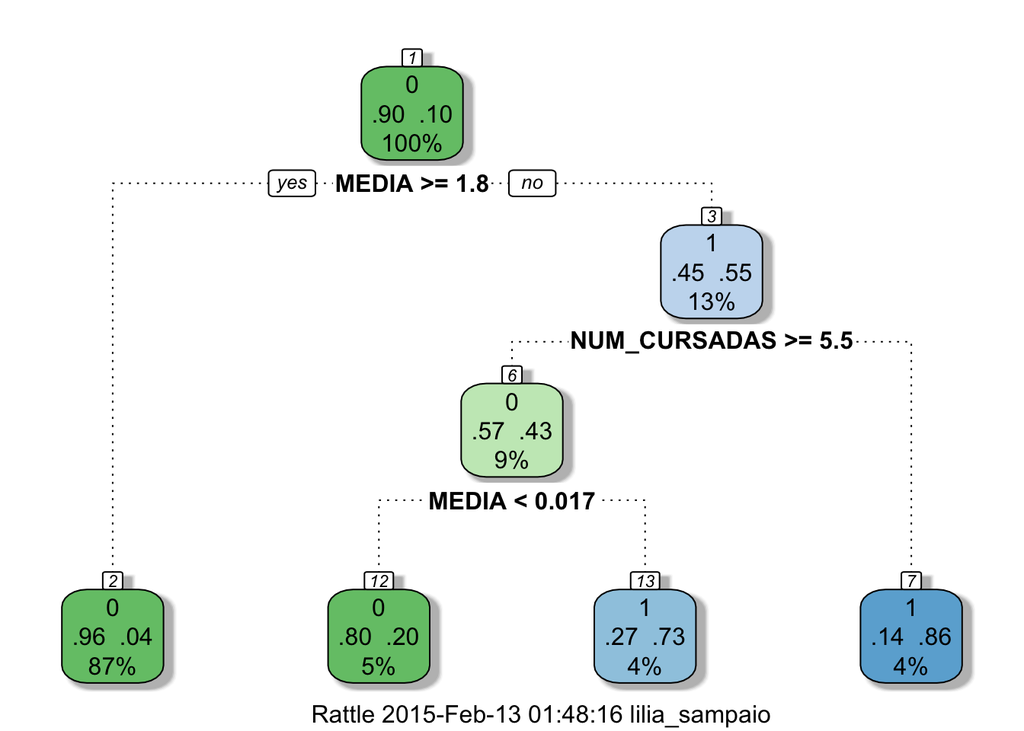

Calculando a predição, teremos que 3 pessoas evadirão.

```r
pred_all_alunos <- predict(tree_all_alunos, teste_all_alunos, type = "class")
summary(pred_all_alunos)
```

```
##  0  1
## 31  3
```

### Alunos de Computação

- Considerando todos os atributos, temos que

```r
tree_comp_alunos <- rpart(COD_EVASAO ~ MEDIA + REPROVADO + REP_FALTA + TRANCOU + NUM_CURSADAS, data=comp_alunos, method="class")
summary(tree_comp_alunos)
```

```
## Call:
## rpart(formula = COD_EVASAO ~ MEDIA + REPROVADO + REP_FALTA +
##     TRANCOU + NUM_CURSADAS, data = comp_alunos, method = "class")
##   n= 243
##
##          CP nsplit rel error    xerror      xstd
## 1 0.4285714      0 1.0000000 1.0000000 0.1777612
## 2 0.0100000      1 0.5714286 0.6071429 0.1420095
##
## Variable importance
##     MEDIA REP_FALTA   TRANCOU
##        55        28        17
##
## Node number 1: 243 observations,    complexity param=0.4285714
##   predicted class=0  expected loss=0.1152263  P(node) =1
##     class counts:   215    28
##    probabilities: 0.885 0.115
##   left son=2 (217 obs) right son=3 (26 obs)
##   Primary splits:
##       MEDIA        < 1.816667 to the right, improve=22.0631000, (0 missing)
##       REP_FALTA    < 1.5      to the left,  improve=12.4126200, (0 missing)
##       TRANCOU      < 0.5      to the left,  improve= 4.2994530, (0 missing)
##       REPROVADO    < 0.5      to the left,  improve= 1.9839940, (0 missing)
##       NUM_CURSADAS < 5.5      to the right, improve= 0.6893043, (0 missing)
##   Surrogate splits:
##       REP_FALTA < 2.5      to the left,  agree=0.947, adj=0.500, (0 split)
##       TRANCOU   < 0.5      to the left,  agree=0.926, adj=0.308, (0 split)
##
## Node number 2: 217 observations
##   predicted class=0  expected loss=0.04147465  P(node) =0.8930041
##     class counts:   208     9
##    probabilities: 0.959 0.041
##
## Node number 3: 26 observations
##   predicted class=1  expected loss=0.2692308  P(node) =0.1069959
##     class counts:     7    19
##    probabilities: 0.269 0.731
```

Também dando uma olhada no campo referente à importancia das variaveis (Variable importance) teremos ainda que a mais importante foi a MEDIA, seguida de REP_FALTA e TRANCOU. Ainda vemos que a arvore so tem o nó Média, sendo esse o mais decisivo para novamente para essa predição.

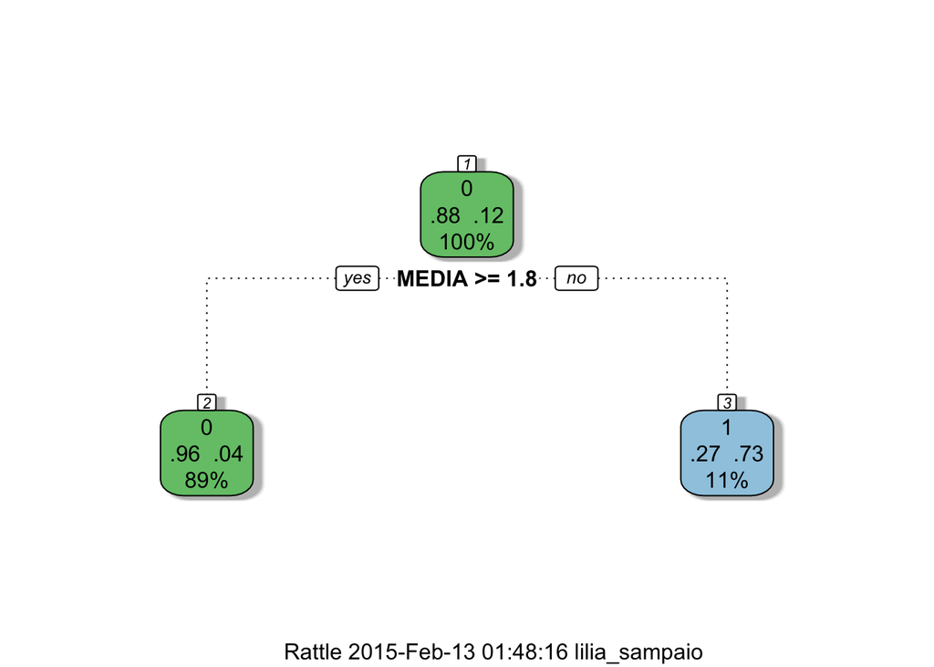

Calculando a predição, teremos que 2 pessoas evadirão.

```r
pred_comp_alunos <- predict(tree_comp_alunos, teste_comp_alunos, type = "class")
summary(pred_comp_alunos)
```

```
##  0  1
## 21  2
```

### Alunos de Engenharia Mecânica

- Considerando todos os atributos, temos que

```r
tree_mec_alunos <- rpart(COD_EVASAO ~ MEDIA + REPROVADO + REP_FALTA + TRANCOU + NUM_CURSADAS, data=mec_alunos, method="class")
summary(tree_mec_alunos)
```

```
## Call:
## rpart(formula = COD_EVASAO ~ MEDIA + REPROVADO + REP_FALTA +
##     TRANCOU + NUM_CURSADAS, data = mec_alunos, method = "class")
##   n= 138
##
##           CP nsplit rel error    xerror      xstd
## 1 0.09090909      0 1.0000000 1.0000000 0.2892451
## 2 0.01000000      2 0.8181818 0.9090909 0.2768680
##
## Variable importance
##        MEDIA      TRANCOU    REP_FALTA NUM_CURSADAS
##           39           35           25            2
##
## Node number 1: 138 observations,    complexity param=0.09090909
##   predicted class=0  expected loss=0.07971014  P(node) =1
##     class counts:   127    11
##    probabilities: 0.920 0.080
##   left son=2 (115 obs) right son=3 (23 obs)
##   Primary splits:
##       MEDIA        < 2.07619   to the right, improve=3.9681160, (0 missing)
##       REP_FALTA    < 2.5       to the left,  improve=2.3984510, (0 missing)
##       NUM_CURSADAS < 4.5       to the right, improve=1.8115940, (0 missing)
##       TRANCOU      < 0.5       to the left,  improve=0.4870272, (0 missing)
##       REPROVADO    < 1.5       to the right, improve=0.2463768, (0 missing)
##   Surrogate splits:
##       TRANCOU   < 0.5       to the left,  agree=0.913, adj=0.478, (0 split)
##       REP_FALTA < 2.5       to the left,  agree=0.891, adj=0.348, (0 split)
##
## Node number 2: 115 observations
##   predicted class=0  expected loss=0.02608696  P(node) =0.8333333
##     class counts:   112     3
##    probabilities: 0.974 0.026
##
## Node number 3: 23 observations,    complexity param=0.09090909
##   predicted class=0  expected loss=0.3478261  P(node) =0.1666667
##     class counts:    15     8
##    probabilities: 0.652 0.348
##   left son=6 (13 obs) right son=7 (10 obs)
##   Primary splits:
##       TRANCOU      < 0.5       to the right, improve=2.25016700, (0 missing)
##       REP_FALTA    < 1.5       to the left,  improve=0.77324410, (0 missing)
##       NUM_CURSADAS < 6.5       to the right, improve=0.08093645, (0 missing)
##   Surrogate splits:
##       REP_FALTA    < 1.5       to the left,  agree=0.870, adj=0.7, (0 split)
##       MEDIA        < 0.5214286 to the left,  agree=0.696, adj=0.3, (0 split)
##       NUM_CURSADAS < 3.5       to the right, agree=0.609, adj=0.1, (0 split)
##
## Node number 6: 13 observations
##   predicted class=0  expected loss=0.1538462  P(node) =0.0942029
##     class counts:    11     2
##    probabilities: 0.846 0.154
##
## Node number 7: 10 observations
##   predicted class=1  expected loss=0.4  P(node) =0.07246377
##     class counts:     4     6
##    probabilities: 0.400 0.600
```

Dessa vez, olhando o campo referente à importancia das variaveis (Variable importance) teremos que, o campo mais importante ainda foi a MEDIA, mas agora seguida de TRANCOU, REP_FALTA e NUM_CURSADAS, diferentemente do considerado só para o curso de Computação, por exemplo. Ainda vemos que a arvore que, para Computação, so tinha o nó Média, agora possui o nó TRANCOU como significativo.

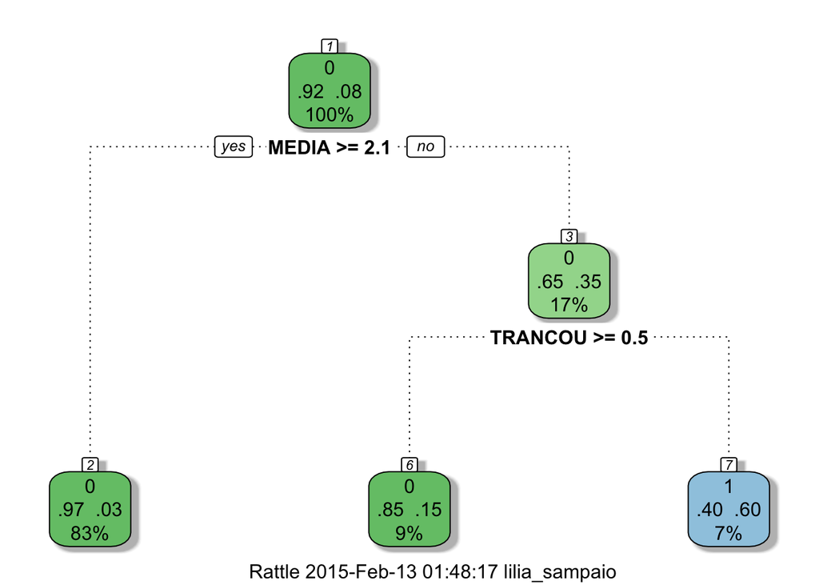

Finalmente, calculando a predição, teremos que 1 pessoa evadirá.

```r
pred_mec_alunos <- predict(tree_mec_alunos, teste_mec_alunos, type = "class")
summary(pred_mec_alunos)
```

```
##  0  1
## 10  1
```